# Trabajo grupal 1 - Sampling Data

Calvo, Andrea; Ibañez, Mauricio; Lévano, Valeria; Núñez, César

2023-09-02

## PARTE 1

1. Descargue el Censo Nacional de Población Penitenciaria 2016 de la página del INEI (http://iinei.inei.gob.pe/microdatos/). Puede descargar solo la carátula o también más módulos de dicho censo.
- Definimos ruta

```r
#Cambiar a donde tengan almacenada la base de datos
setwd("C:/Users/User/Documents/GitHub/Diplomado_PUCP/Big Data")
```

- Leemos la base

```r
data<-read_sav("01_PENALES_CARATULA.sav")
```

2. Genere una variable dicotómica con el valor de 1 para quienes cometen “Delitos contra la libertad”, 0 para los demás casos. Llamar a esta variable “pp_dcl”

```
## [1] "DELITOS CONTRA LA LIBERTAD"          "DELITOS CONTRA LA SEGURIDAD PUBLICA"
## [3] "DELITOS CONTRA EL PATRIMONIO"        "DELITOS CONTRA LA SEGURIDAD PUBLICA"
## [5] "DELITOS CONTRA LA SEGURIDAD PUBLICA" "DELITOS CONTRA LA SEGURIDAD PUBLICA"
```

```r
data$pp_dcl <-  if_else(data$DELITO_GENERICO == 'DELITOS CONTRA LA LIBERTAD', 1, 0)
```

3. Establecer una semilla (“seed”) usando los dígitos del código PUCP de alguno de los miembros del grupo

```r
set.seed(20176040)
```

4. Extraer una muestra estratificada y por conglomerados que contenga entre el 1% y 5% de la población (toda la base). Especificar qué variables se utilizan para los estratos y conglomerados y discutir por qué son adecuadas para dicho propósito. Discutir también si hay otras variables que podrían haberse utilizado para los estratos o conglomerados.

La idea es crear estratos en base al número de presos por establecimiento peninteciario. De esta forma dividiremos a los establecimientos (clusters) de acuerdo a su tamaño. Antes de ello, seleccionaremos aleatoriamente a los cluster que seleccionaremos para el análisis.

- Creamos base conglomerados

```r
base_clusters <- data %>%
  count(EST_PENIT_COD)
```

- Revisamos cuantos presos hay por establecimiento peninteciario para crear los estratos

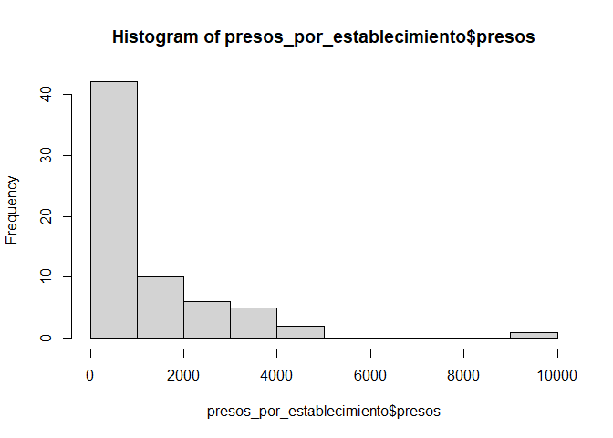

```r
data <- data %>%
  mutate(presos = 1)

presos_por_establecimiento <- aggregate(presos ~ EST_PENIT_COD, data = data, FUN = sum)

hist(presos_por_establecimiento$presos)
```

- Crearemos estratos en base al número de reclusos por establecimiento penitenciario:

```r
data <- data %>%
  group_by(EST_PENIT_COD) %>%
  mutate(num_presos_total = n()) %>%
  ungroup()
```

```r
data = data %>%
  mutate(estrato = case_when(num_presos_total < 1500 ~ 1,
                            num_presos_total < 3500 ~ 2,
                               T ~ 3))
```

- Revisamos el número observaciones en cada estrato

```r
table(data$estrato)
```

```
##
##     1     2     3
## 19573 34232 22375
```

- Seleccionamos aleatoriamente a los conglomerados por estrato.

```r
estratos <- distinct(data, estrato, EST_PENIT_COD) %>%
  select(estrato, EST_PENIT_COD)

data1 <- merge(x = base_clusters , y = estratos , by = c("EST_PENIT_COD"))

#Seleccioamos al 80% de cluster por cada estrato
set.seed(20176040)
mac1_clusters <- data1 %>%
   group_by(estrato) %>%
  slice_sample(prop = 0.8)

table(mac1_clusters$estrato)
```

```
##
##  1  2  3
## 38 11  3
```

```r
#Unimos las bases para quedarnos con los conglomerados seleccionados por cada estrato.
mac1_f <- merge(x = data , y = mac1_clusters , by = c("EST_PENIT_COD"))
```

- Obtenemos la muestra con el 5% de de la muestra conglomerada. Aleatorizamos por estrato y cluster.

```r
set.seed(20176040)
muestra <- mac1_f %>%
  group_by(estrato.x,EST_PENIT_COD) %>%
  sample_n(if_else(n() <= 13, 1, round(n() * 0.05)))
```

```r
table(muestra$estrato.x)
```

```
##
##    1    2    3
##  799 1373  901
```

```r
table(data$estrato)
```

```
##
##     1     2     3
## 19573 34232 22375
```

Ahora, nosotros seleccionamos el tamaño de las centros penitenciarios porque deseamos realizar un análisis en base a ello. Ahora, también podríamos haber analizado en base a las regiones. Es decir, se pudo haber estratificado por regiones y los conglomerados son los centros peninteciarios. Seleccionandose una muestra por cada centro. También hay variables como religion, situación jurídica, etc. Depende del tipo de análisis que se desee realizar.

5. Declarar el diseño muestral (completo) y obtener las siguientes estadísticas (deben ser representativas):
- Creamos los pesos

```r
# Creamos los p

p2 <- vector("numeric", length = 3)

for (i in 1:3) {
  data_estrato <- data[data$estrato == i, ]
  muestra_estrato <- muestra[muestra$estrato.x == i, ]

p2[i] <- n_distinct(data_estrato$EST_PENIT_COD) / n_distinct(muestra_estrato$EST_PENIT_COD)
}
```

```r
unique(muestra$EST_PENIT_COD)
```

```
##  [1] 101 102 103 104 105 107 110 111 201 204 210 213 214 215 218 303 305 306 402
## [20] 403 404 407 409 410 502 602 606 607 701 702 703 704 705 707 708 709 801 802
## [39] 108 109 202 203 206 207 208 209 301 405 501 106 205 216
```

```r
muestra <- muestra %>%
  mutate(pwe = case_when(
      estrato.x == 1 ~ (799/19573)*p2[1],
      estrato.x == 2 ~ (1373/34232)*p2[2],
      estrato.x == 3 ~ (901/22375)*p2[3]), .keep = "all")
```

```r
head(muestra$pwe)
```

```
## [1] 0.05156405 0.05156405 0.05156405 0.05156405 0.05156405 0.05156405
```

```r
data_svy = svydesign(id = ~EST_PENIT_COD , strata = ~estrato.x , weights = ~pwe, data = muestra)
```

1. Porcentaje de personas que ha cometido “Delitos contra la libertad”

```r
svymean(~pp_dcl, data_svy)
```

```
##          mean     SE
## pp_dcl 0.1797 0.0182
```

2. Total de personas que ha cometido “Delitos contra la libertad”

```r
svytotal(~pp_dcl, data_svy)
```

```
##         total     SE
## pp_dcl 28.692 2.8702
```

## PARTE 2

1. Explicar el diseño muestral de la encuesta. Luego, declarar el diseño muestral (completo). Para esto se recomienda revisar la ficha técnica de la encuesta. Esta se encuentra disponible en la web de microdatos del INEI. (2 puntos)

La Encuesta Demográfica y de Salud Familiar - ENDES provee información actualizada sobre la dinámica demográfica, el estado de salud de las madres y niños menores de cinco años, así como también brindar información sobre el estado y factores asociados a las enfermedades no transmisibles y transmisibles, así como el acceso a servicios de diagnóstico y tratamiento.

Para la selección de la muestra se utilizó la información estadística y cartográfica proveniente de los Censos Nacionales XII de Población y VII de Vivienda del año 2017 (CPV 2017), y el material cartográfico actualizado para tal fin en el proceso de actualización cartográfica realizado para la ejecución de la ENDES.

La unidad primaria de muestreo (UPM) es el conglomerado La unidad secundaria de muestreo (USM) corresponde a las viviendas particulares

La muestra se caracteriza por ser bietápica, probabilística de tipo equilibrado, estratificada e independiente, a nivel departamental, por área urbana y rural.

```r
# Importar la base de datos
basedatos<-read.csv2('RECH0.csv')


# Declarar el diseño muestral completo
encuesta_design <- svydesign(
  id = ~HV001,  # Variable de conglomerados
  strata = ~HV022,  # Variable de estratos
  data = basedatos, # Base de datos
  weights = ~HV005  # Factor de ponderación
)
```

2. Elegir y calcular dos variables: (i) una dicotómica, (ii) una continua. Por lo menos la variable dicotómica debe ser una variable definida y creada por ustedes. (2 puntos)
1. 22. dicotómica : Variable de encuesta completa construída a partir de HV015 donde encuesta_completada toma valor de 1 cuando la respuesta es completa y 0 caso contrario.

1 Completo; 2 Hogar presente pero entrevistado ausente; 3 Hogar ausente; 5 Rechazada; 6 Vivienda desocupada o no es vivienda; 7 Vivienda destruida; 8 Vivienda no encontrada; 9 Otro

```r
basedatos$encuesta_completada <- ifelse(basedatos$HV015 %in% c(2, 3, 5, 6, 7, 8, 9), 0, 1)
View(basedatos$encuesta_completada)
```

2. v.continua : Variable que normaliza la variable LONGITUDX (Longitud del conglomerado) para que los valores estén en el rango de 0 a 1.

```r
basedatos$longitud_normalizada <- (basedatos$LONGITUDX - min(basedatos$LONGITUDX)) / (max(basedatos$LONGITUDX) - min(basedatos$LONGITUDX))
View(basedatos$longitud_normalizada)
```

3. Para la dicotómica, obtener la media y población. Para la continua, obtener la media (deben ser representativas). (3 puntos)

```r
media_dicotomica <- mean(basedatos$encuesta_completada)
poblacion_dicotomica <- sum(basedatos$encuesta_completada)
media_continua <- mean(basedatos$longitud_normalizada)
cat("Media de la variable dicotómica:", media_dicotomica, "\n")
```

```
## Media de la variable dicotómica: 0.9183668
```

```r
cat("Población de la variable dicotómica :", poblacion_dicotomica, "\n")
```

```
## Población de la variable dicotómica : 34301
```

```r
cat("Media de la variable continua :", media_continua, "\n")
```

```
## Media de la variable continua : 0.4728052
```

## PARTE 3

BLOQUE B

### Pregunta 1 (Palabras: 500)

Un muestreo por conglomerados de una sola etapa resultaría muy costoso y poco eficiente. Por un lado, si se randomiza la selección de distritos a nivel nacional para luego “censar” a los niños en educación primaria puede llegar a ser muy costoso porque no necesariamente todos los hogares del distrito cuentan con niños en educación primaria. Es decir, tendrías que censar para asegurar que estas consiguiendo la información que necesitas. Por otro lado, al censar en dentro de los distritos seleccionados aleatoriamente es probable que exista una alta correlación intraclusters (es probable que los niños del mismo distrito cuenten con características socioeconómicas homogéneas) lo cual ofrece poca varianza sobre la variable de interés lo cual implica pérdida de eficiencia significativa en el muestreo por conglomerados respecto a un muestreo aleatorio simple (el efecto de diseño o deff sería mayor a 1).

Creemos que se puede establecer un mejor diseño muestral para medir indicadores de desnutrición en la población de escolares de educación primaria. Para ello, una primera observación propuesta es delimitar mejor la población de interés. Se propone delimitar la muestra a alumnos del primer, tercero y sexto grado de primaria con la finalidad de poder medir evaluar el indicador de interés al inicio de la primaria, a mitad del nivel escolar y a punto de culminar el mismo. Una vez delimitado el universo de interés se propone pasar a un muestreo por conglomerados en dos etapas. Se define como unidad primaria de muestreo (UPM) a las Unidades de Gestión Educativa Local (UGEL) con colegios de nivel primario. Estas agrupan colegios incluso de distintos distritos y abarcan todo el territorio nacional. Luego, se define como unidad secundaria de muestreo a colegios que ofrecen servicios educativos de nivel primario dentro de cada UGEL. Una vez seleccionados los colegios como parte de la muestra final, se recogerá información estilo “censo” de cada uno de los alumnos de que conforman el primer, tercero y sexto grado de primaria.

Se podría evaluar la posibilidad de añadir una tercera unidad de muestreo dentro de cada grado para seleccionar solo un grupo de niños y niñas. Además, se puede aprovechar esta tercera etapa para estratificar la muestra según sexo del escolar. Creemos que esta tercera etapa estratificada puede disminuir el valor del deff dado que el indicador de desnutrición no en los escolares no estaría fuertemente ligado a la selección de la UGEL ni de la escuela, lo cual nos permite ganar eficiencia con el diseño

El diseño planteado por el muestrista favorece la reducción de costos de implementación de la encuesta. Sin embargo, sabemos que el efecto de diseño puede ser superior a 1 (lo cual implica una pérdida de eficiencia respecto a un muestreo aleatorio simple) si es que la correlación intracluster es muy alta. Ello debido a que al hacer un muestreo por conglomerados se espera que las primeras unidades de muestreo sean homogéneas entre los grupos y heterogéneos entre las segundas unidades de muestreo y al no ser los colegios diferentes entre sí, puede perjudicar el efecto de diseño. En cambio, un muestreo estratificado reduce el efecto de diseño, sin embargo, es mucho más costoso ya que consideraría a toda la población.

### Pregunta 2 (Palabras: 300)

La ENA más reciente es la del 2022. De acuerdo con la ficha técnica de esta encuesta, no es posible obtener información distrital confiable respecto al acceso a asistencia técnica de agricultores en los distritos de Ayacucho. Esto debido a que los niveles de inferencia o los dominios que fueron utilizados en el diseño muestral sólo permiten obtener indicadores confiables hasta el nivel departamental para pequeños y medianos productores agropecuarios. Esto implica que no se obtuvo una muestra aleatoria para cada distrito, lo cual nos permitiría obtener estimadores insesgados a nivel distrital.

De hecho, como se menciona en la documentación de la encuesta “La muestra fue probabilística, estratificada, bietápica, independiente en cada departamento, de selección sistemática con probabilidad proporcional al tamaño en la primera etapa y sistemática simple en la segunda etapa.”. Esto implica que se desarrolló un muestreo complejo independiente para cada departamento y, dentro de cada uno, se estratificó por región natural y tamaño de la unidad agropecuaria, y se definieron 2096 conglomerados los cuales fueron aleatorizados en una primera etapa con pesos heterogéneos y luego dentro de cada conglomerado se realizó una aleatorización simple.

De lo anterior, se puede reafirmar que no es lo óptimo obtener estadísticas distritales de la ENA porque: (i) puede que los distritos no hayan sido seleccionados en la primera etapa (aleatorización de conglomerados), (ii) puede que existan algunas unidades agropecuarias, pero estas no forman parte de una muestra aleatoria del distrito por lo cual no garantiza la insesgadez de las estimaciones que se puedan realizar.

Lo recomendable para poder hacer las estadísticas que propone el hacedor de políticas públicas es utilizar el Censo Nacional Agropecuario que, aunque es del 2012, sí permite obtener la información requerida a nivel distrital de manera certera puesto que no es una muestra, sino un censo.